# Taller práctico de Web Scraping con R Parte 1

Curso de Minería de Datos

Andrés Felipe Flórez Rivera

2026-04-13

Universidad Nacional de Colombia — Departamento de Estadística, Sede Bogotá

## Introducción

En un flujo de análisis de datos, el **web scraping** corresponde a la fase de **recolección de datos**, que constituye el primer paso dentro del proceso de descubrimiento de conocimiento. En muchos contextos reales, los datos no están disponibles en formatos estructurados ni en bases de datos listas para analizar, sino **dispersos en páginas web**, catálogos en línea o plataformas digitales. En este escenario, el **web scraping** se convierte en una herramienta fundamental, ya que **permite automatizar** la extracción de información y transformarla en **datos estructurados**, facilitando su posterior análisis.

## 1. ¿Qué es web scraping?

El **web scraping** es una técnica para extraer información desde páginas web de forma automatizada. En lugar de copiar y pegar manualmente datos desde el navegador, escribimos código que:

1. solicita la página,
2. interpreta su estructura HTML,
3. identifica los elementos de interés,
4. extrae la información,
5. la transforma en una tabla lista para analizar.

## ¿Cuándo es útil?

Es especialmente útil cuando:

- la información está publicada en la web, pero no existe una API;
- necesitamos recolectar datos repetidamente;
- deseamos construir una base de datos a partir de múltiples páginas;
- queremos monitorear cambios en precios, textos, listados o indicadores públicos.

# 2. HTML y CSS

- **HTML** es el lenguaje que define la estructura de una página web; indica qué es un título, un párrafo o un enlace, y ahí es donde están organizados los datos que luego se pueden extraer.

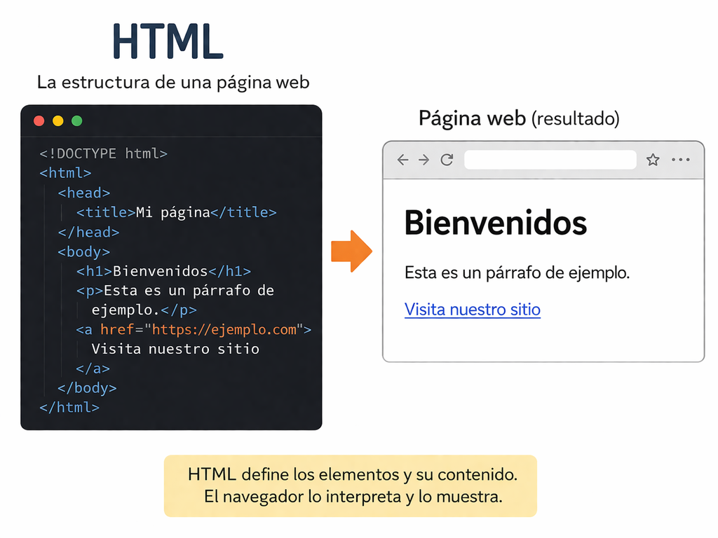

Al inspeccionar el código fuente de una página, es común encontrar etiquetas como estas:

- `<h1>` para adicionar títulos,
- `<p>` para adicionar párrafos,
- `<a>` para adicionar enlaces,
- `<table>` para adicionar tablas,
- `<div>` y `<span>` para adicionar bloques y fragmentos,
- atributos como `class`, `id` y `href`.
- **CSS** es el lenguaje que se usa para darle estilo a la página; controla colores, tamaños y diseño visual, pero no cambia ni agrega contenido, solo cómo se ve.

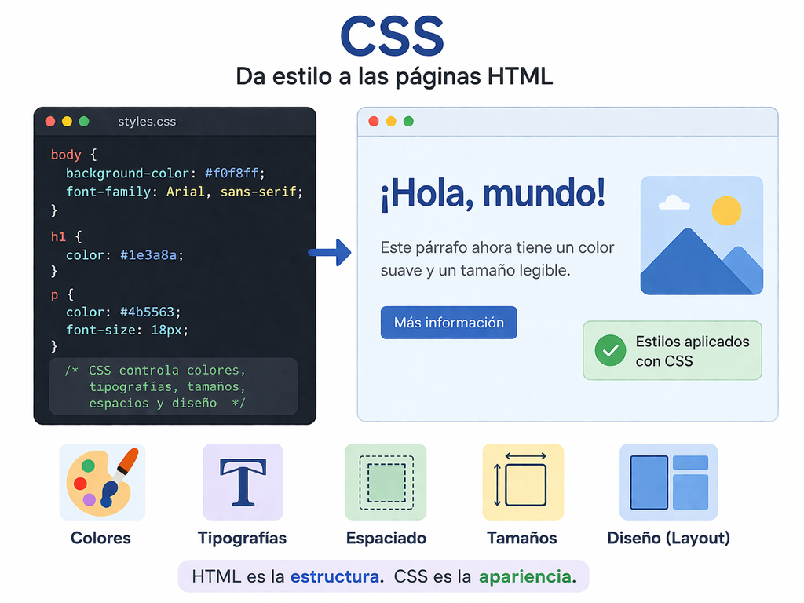

En scraping casi siempre usamos **selectores CSS** o, a veces, **XPath**.

- Un **selector CSS** es una forma de decirle a R (python) qué elementos del HTML queremos localizar, por ejemplo un título, un enlace o un bloque de productos. Funciona como una regla de búsqueda basada en etiquetas, clases, ids o combinaciones entre ellas.
- Un **XPath** cumple una idea parecida, pero describe la ubicación de un nodo dentro de la estructura del documento como si recorriéramos un árbol. Suele ser útil cuando necesitamos una ruta más específica o cuando el selector CSS no es suficiente.

En la práctica, normalmente empezamos con **selectores CSS** porque suelen ser más simples de leer, y recurrimos a **XPath** cuando la estructura de la página exige una búsqueda más precisa.

## 3. Paquetes que usaremos

En este taller trabajaremos principalmente con:

- `rvest`:
  - `read_html()`: lee el HTML de una URL y lo convierte en un documento analizable.
  - `html_element()`: extrae el primer elemento que coincide con un selector CSS.
  - `html_elements()`: extrae todos los elementos que coinciden con un selector CSS.
  - `html_text2()`: obtiene el texto visible de un nodo con espacios más limpios.
  - `html_attr()`: extrae el valor de un atributo como `href`, `title` o `class`.
  - `html_table()`: convierte tablas HTML en data frames de R.
- `dplyr`:
  - `mutate()`: crea o transforma columnas.
  - `count()`: resume frecuencias por categoría.
  - `summarise()`: calcula resúmenes agregados.
  - `n()`: cuenta filas dentro de un resumen.
  - `n_distinct()`: cuenta valores únicos.
  - `if_else()`: crea variables condicionales.
  - `select()`: selecciona columnas de interés.
- `stringr`:
  - `str_replace_all()`: reemplaza patrones de texto en una cadena.
  - `str_squish()`: elimina espacios sobrantes y compacta el texto.
  - `str_count()`: cuenta ocurrencias de un patrón.
  - `str_remove()`: elimina una parte del texto.
  - `str_detect()`: verifica si un patrón aparece en una cadena.
  - `str_to_lower()`: convierte texto a minúsculas.
- `purrr`:
  - `map_dfr()`: recorre elementos y une los resultados en una tabla.
  - `possibly()`: crea una versión segura de una función para manejar errores.
- `janitor`:
  - `clean_names()`: estandariza nombres de variables para que sean más fáciles de usar.
- `readr`:
  - `write_csv()`: guarda una tabla en formato CSV.
- `knitr`: presentación del documento y formateo de tablas.
  - `opts_chunk$set()`: define opciones globales de los chunks del documento.
  - `kable()`: da formato legible a las tablas del reporte.
  - `is_html_output()`: detecta si la salida actual es HTML.
  - `asis_output()`: inserta contenido HTML directamente en la salida del documento.

En Python los equivalentes son: `requests`, `beautifulsoup4`, `pandas`, `re` y `lxml`.

# 4. Leer una página web

### Cargamos los paquetes necesarios

#### R

```r
paquetes <- c(
                "rvest", "xml2", "dplyr", "stringr",
                "purrr", "janitor", "readr", "knitr"
              )
# Verificamos qué paquetes faltan
instalados <- rownames(installed.packages())
pendientes <- setdiff(paquetes, instalados)

if (length(pendientes) > 0) {
  install.packages(pendientes)
}

# Cargamos los paquetes sin mostrar mensajes
invisible(lapply(paquetes, library, character.only = TRUE))
```

#### Python

```python
# Instalamos los paquetes necesarios (desde terminal)
# pip install requests beautifulsoup4 pandas lxml

import requests
from bs4 import BeautifulSoup
import pandas as pd
import re
```

### Usaremos un sitio hecho para practicar scraping: **Quotes to Scrape**.

#### R

```r
url_quotes <- "https://quotes.toscrape.com/"

# Leemos el HTML de la página
pagina_quotes <- read_html(url_quotes)
pagina_quotes
```

```
## {html_document}
## <html lang="en">
## [1] <head>\n<meta http-equiv="Content-Type" content="text/html; charset=UTF-8 ...
## [2] <body>\n    <div class="container">\n        <div class="row header-box"> ...
```

#### Python

```python
url_quotes = "https://quotes.toscrape.com/"

# Hacemos la petición y parseamos el HTML
respuesta = requests.get(url_quotes)
pagina_quotes = BeautifulSoup(respuesta.text, "lxml")
print(pagina_quotes.prettify()[:500])  # Preview del HTML
```

### Extraer el título de la página

#### R

```r
pagina_quotes %>%
  html_element("title") %>%
  html_text2()
```

```
## [1] "Quotes to Scrape"
```

#### Python

```python
pagina_quotes.find("title").get_text()
```

### Extraer todos los textos de las citas

#### R

```r
citas <- pagina_quotes %>%
  html_elements(".quote .text") %>%
  html_text2()

citas
```

```
##  [1] "“The world as we have created it is a process of our thinking. It cannot be changed without changing our thinking.”"
##  [2] "“It is our choices, Harry, that show what we truly are, far more than our abilities.”"
##  [3] "“There are only two ways to live your life. One is as though nothing is a miracle. The other is as though everything is a miracle.”"
##  [4] "“The person, be it gentleman or lady, who has not pleasure in a good novel, must be intolerably stupid.”"
##  [5] "“Imperfection is beauty, madness is genius and it's better to be absolutely ridiculous than absolutely boring.”"
##  [6] "“Try not to become a man of success. Rather become a man of value.”"
##  [7] "“It is better to be hated for what you are than to be loved for what you are not.”"
##  [8] "“I have not failed. I've just found 10,000 ways that won't work.”"
##  [9] "“A woman is like a tea bag; you never know how strong it is until it's in hot water.”"
## [10] "“A day without sunshine is like, you know, night.”"
```

#### Python

```python
citas = [el.get_text(strip=True) for el in pagina_quotes.select(".quote .text")]
citas
```

### Extraer los autores

#### R

```r
autores <- pagina_quotes %>%
  html_elements(".quote .author") %>%
  html_text2()

autores
```

```
##  [1] "Albert Einstein"   "J.K. Rowling"      "Albert Einstein"
##  [4] "Jane Austen"       "Marilyn Monroe"    "Albert Einstein"
##  [7] "André Gide"        "Thomas A. Edison"  "Eleanor Roosevelt"
## [10] "Steve Martin"
```

#### Python

```python
autores = [el.get_text(strip=True) for el in pagina_quotes.select(".quote .author")]
autores
```

### Construir una tabla para almacenar las citas

#### R

```r
# Creamos la tabla
tabla_citas <- tibble(
  cita = citas,
  autor = autores
)

# Mostramos las citas en una tabla
mostrar_tabla(tabla_citas, n = 10, caption = "Primeras citas extraídas")
```

Primeras citas extraídas

| cita | autor |
| --- | --- |
| “The world as we have created it is a process of our thinking. It cannot be changed without changing our thinking.” | Albert Einstein |
| “It is our choices, Harry, that show what we truly are, far more than our abilities.” | J.K. Rowling |
| “There are only two ways to live your life. One is as though nothing is a miracle. The other is as though everything is a miracle.” | Albert Einstein |
| “The person, be it gentleman or lady, who has not pleasure in a good novel, must be intolerably stupid.” | Jane Austen |
| “Imperfection is beauty, madness is genius and it’s better to be absolutely ridiculous than absolutely boring.” | Marilyn Monroe |
| “Try not to become a man of success. Rather become a man of value.” | Albert Einstein |
| “It is better to be hated for what you are than to be loved for what you are not.” | André Gide |
| “I have not failed. I’ve just found 10,000 ways that won’t work.” | Thomas A. Edison |
| “A woman is like a tea bag; you never know how strong it is until it’s in hot water.” | Eleanor Roosevelt |
| “A day without sunshine is like, you know, night.” | Steve Martin |

#### Python

```python
# Creamos el DataFrame
tabla_citas = pd.DataFrame({"cita": citas, "autor": autores})

# Mostramos las primeras filas
tabla_citas.head(10)
```

# 5. Citas, autores y etiquetas

### Ahora construiremos una tabla completa. Además del texto y el autor, extraeremos las etiquetas asociadas a cada cita.

#### R

```r
nodos_citas <- pagina_quotes %>%
               html_elements(".quote")
length(nodos_citas)
```

```
## [1] 10
```

#### Python

```python
nodos_citas = pagina_quotes.select(".quote")
len(nodos_citas)
```

### Extraer información por bloque

En vez de buscar cada dato por separado en toda la página, tomamos cada bloque que representa una unidad lógica y extraemos sus partes internas.

#### R

```r
tabla_citas_completa <- map_dfr(nodos_citas, function(nodo) {
  cita <- nodo %>% html_element(".text") %>% html_text2()
  autor <- nodo %>% html_element(".author") %>% html_text2()
  tags <- nodo %>% html_elements(".tags .tag") %>% html_text2()

  tibble(
    cita = cita,
    autor = autor,
    tags = paste(tags, collapse = ", ")
  )
})

mostrar_tabla(tabla_citas_completa, n = 10, caption = "Citas, autores y etiquetas")
```

Citas, autores y etiquetas

| cita | autor | tags |
| --- | --- | --- |
| “The world as we have created it is a process of our thinking. It cannot be changed without changing our thinking.” | Albert Einstein | change, deep-thoughts, thinking, world |
| “It is our choices, Harry, that show what we truly are, far more than our abilities.” | J.K. Rowling | abilities, choices |
| “There are only two ways to live your life. One is as though nothing is a miracle. The other is as though everything is a miracle.” | Albert Einstein | inspirational, life, live, miracle, miracles |
| “The person, be it gentleman or lady, who has not pleasure in a good novel, must be intolerably stupid.” | Jane Austen | aliteracy, books, classic, humor |
| “Imperfection is beauty, madness is genius and it’s better to be absolutely ridiculous than absolutely boring.” | Marilyn Monroe | be-yourself, inspirational |
| “Try not to become a man of success. Rather become a man of value.” | Albert Einstein | adulthood, success, value |
| “It is better to be hated for what you are than to be loved for what you are not.” | André Gide | life, love |
| “I have not failed. I’ve just found 10,000 ways that won’t work.” | Thomas A. Edison | edison, failure, inspirational, paraphrased |
| “A woman is like a tea bag; you never know how strong it is until it’s in hot water.” | Eleanor Roosevelt | misattributed-eleanor-roosevelt |
| “A day without sunshine is like, you know, night.” | Steve Martin | humor, obvious, simile |

#### Python

```python
registros = []
for nodo in nodos_citas:
    cita  = nodo.select_one(".text").get_text(strip=True)
    autor = nodo.select_one(".author").get_text(strip=True)
    tags  = [t.get_text(strip=True) for t in nodo.select(".tags .tag")]
    registros.append({"cita": cita, "autor": autor, "tags": ", ".join(tags)})

tabla_citas_completa = pd.DataFrame(registros)
tabla_citas_completa.head(10)
```

## 6. Limpieza básica del texto extraído

Es común que los textos traigan comillas, espacios extra o saltos de línea.

### Código

#### R

```r
tabla_citas_limpia <- tabla_citas_completa %>%
  mutate(
    # Quitamos las comillas tipográficas de la cita
    cita = str_replace_all(cita, "[\u201c\u201d]", ""),
    # Eliminamos espacios sobrantes en el texto de la cita
    cita = str_squish(cita),
    # Limpiamos espacios innecesarios en el nombre del autor
    autor = str_squish(autor),
    # Calculamos cuántas etiquetas tiene cada cita
    n_tags = if_else(tags == "", 0L, str_count(tags, ",") + 1L)
  )

mostrar_tabla(tabla_citas_limpia, n = 10, caption = "Citas limpias con número de etiquetas")
```

Citas limpias con número de etiquetas

| cita | autor | tags | n_tags |
| --- | --- | --- | --- |
| The world as we have created it is a process of our thinking. It cannot be changed without changing our thinking. | Albert Einstein | change, deep-thoughts, thinking, world | 4 |
| It is our choices, Harry, that show what we truly are, far more than our abilities. | J.K. Rowling | abilities, choices | 2 |
| There are only two ways to live your life. One is as though nothing is a miracle. The other is as though everything is a miracle. | Albert Einstein | inspirational, life, live, miracle, miracles | 5 |
| The person, be it gentleman or lady, who has not pleasure in a good novel, must be intolerably stupid. | Jane Austen | aliteracy, books, classic, humor | 4 |
| Imperfection is beauty, madness is genius and it’s better to be absolutely ridiculous than absolutely boring. | Marilyn Monroe | be-yourself, inspirational | 2 |
| Try not to become a man of success. Rather become a man of value. | Albert Einstein | adulthood, success, value | 3 |
| It is better to be hated for what you are than to be loved for what you are not. | André Gide | life, love | 2 |
| I have not failed. I’ve just found 10,000 ways that won’t work. | Thomas A. Edison | edison, failure, inspirational, paraphrased | 4 |
| A woman is like a tea bag; you never know how strong it is until it’s in hot water. | Eleanor Roosevelt | misattributed-eleanor-roosevelt | 1 |
| A day without sunshine is like, you know, night. | Steve Martin | humor, obvious, simile | 3 |

#### Python

```python
tabla_citas_limpia = tabla_citas_completa.copy()

# Quitamos las comillas tipográficas y compactamos espacios
tabla_citas_limpia["cita"] = (
    tabla_citas_limpia["cita"]
    .str.replace(r'[\u201c\u201d]', "", regex=True)
    .str.split().str.join(" ")       # equivalente a str_squish
)
tabla_citas_limpia["autor"] = tabla_citas_limpia["autor"].str.split().str.join(" ")

# Calculamos cuántas etiquetas tiene cada cita
tabla_citas_limpia["n_tags"] = tabla_citas_limpia["tags"].apply(
    lambda x: 0 if x == "" else len(x.split(", "))
)

tabla_citas_limpia.head(10)
```

## Resumen rápido

### Código

#### R

```r
tabla_citas_limpia %>%
  count(autor, sort = TRUE) %>%
  mostrar_tabla(n = 10, caption = "Autores con más citas")
```

Autores con más citas

| autor | n |
| --- | --- |
| Albert Einstein | 3 |
| André Gide | 1 |
| Eleanor Roosevelt | 1 |
| J.K. Rowling | 1 |
| Jane Austen | 1 |
| Marilyn Monroe | 1 |
| Steve Martin | 1 |
| Thomas A. Edison | 1 |

#### Python

```python
(tabla_citas_limpia
    .groupby("autor")
    .size()
    .reset_index(name="n")
    .sort_values("n", ascending=False)
    .head(10))
```

## 7. Navegar varias páginas

Muchas veces la información no está en una sola URL. En este sitio hay paginación. Vamos a scrapear varias páginas y unir los resultados.

## Crear vector de URLs

### Código

#### R

```r
urls_paginas_quotes <- c(
  "https://quotes.toscrape.com/page/1/",
  "https://quotes.toscrape.com/page/2/",
  "https://quotes.toscrape.com/page/3/"
)

urls_paginas_quotes
```

```
## [1] "https://quotes.toscrape.com/page/1/" "https://quotes.toscrape.com/page/2/"
## [3] "https://quotes.toscrape.com/page/3/"
```

#### Python

```python
urls_paginas_quotes = [
    "https://quotes.toscrape.com/page/1/",
    "https://quotes.toscrape.com/page/2/",
    "https://quotes.toscrape.com/page/3/"
]
urls_paginas_quotes
```

### Creamos una función para scrapear una página

#### R

```r
# Definimos una función que recibe la URL de una página
scrapear_quotes <- function(url) {
  # Leemos el HTML de la página
  pagina <- read_html(url)
  # Seleccionamos todos los bloques que contienen citas
  nodos <- pagina %>% html_elements(".quote")

  # Recorremos cada bloque de cita y unimos los resultados en una tabla
  map_dfr(nodos, function(nodo) {
    # Extraemos el texto de la cita
    cita <- nodo %>% html_element(".text") %>% html_text2()
    # Extraemos el nombre del autor
    autor <- nodo %>% html_element(".author") %>% html_text2()
    # Extraemos todas las etiquetas asociadas a la cita
    tags <- nodo %>% html_elements(".tag") %>% html_text2()

    # Construimos una fila con la información extraída
    tibble(
      # Guardamos la URL de origen
      url_origen = url,
      # Limpiamos comillas y espacios del texto de la cita
      cita = str_squish(str_replace_all(cita, "[\u201c\u201d]", "")),
      # Limpiamos espacios extra en el nombre del autor
      autor = str_squish(autor),
      # Unimos las etiquetas en un solo texto separado por comas
      tags = paste(tags, collapse = ", ")
    )
  })
}
```

#### Python

```python
def scrapear_quotes(url):
    pagina = BeautifulSoup(requests.get(url).text, "lxml")
    nodos  = pagina.select(".quote")
    registros = []
    for nodo in nodos:
        cita  = nodo.select_one(".text").get_text(strip=True)
        autor = nodo.select_one(".author").get_text(strip=True)
        tags  = [t.get_text(strip=True) for t in nodo.select(".tag")]
        registros.append({
            "url_origen": url,
            # Limpiamos comillas y espacios
            "cita": " ".join(re.sub(r'[\u201c\u201d]', "", cita).split()),
            "autor": " ".join(autor.split()),
            "tags": ", ".join(tags)
        })
    return pd.DataFrame(registros)
```

## Aplicar la función a varias páginas

### Código

#### R

```r
quotes_tres_paginas <- map_dfr(urls_paginas_quotes, scrapear_quotes)
mostrar_tabla(quotes_tres_paginas, n = 10, caption = "Resultados combinados de varias páginas")
```

Resultados combinados de varias páginas

| url_origen | cita | autor | tags |
| --- | --- | --- | --- |
| https://quotes.toscrape.com/page/1/ | The world as we have created it is a process of our thinking. It cannot be changed without changing our thinking. | Albert Einstein | change, deep-thoughts, thinking, world |
| https://quotes.toscrape.com/page/1/ | It is our choices, Harry, that show what we truly are, far more than our abilities. | J.K. Rowling | abilities, choices |
| https://quotes.toscrape.com/page/1/ | There are only two ways to live your life. One is as though nothing is a miracle. The other is as though everything is a miracle. | Albert Einstein | inspirational, life, live, miracle, miracles |
| https://quotes.toscrape.com/page/1/ | The person, be it gentleman or lady, who has not pleasure in a good novel, must be intolerably stupid. | Jane Austen | aliteracy, books, classic, humor |
| https://quotes.toscrape.com/page/1/ | Imperfection is beauty, madness is genius and it’s better to be absolutely ridiculous than absolutely boring. | Marilyn Monroe | be-yourself, inspirational |
| https://quotes.toscrape.com/page/1/ | Try not to become a man of success. Rather become a man of value. | Albert Einstein | adulthood, success, value |
| https://quotes.toscrape.com/page/1/ | It is better to be hated for what you are than to be loved for what you are not. | André Gide | life, love |
| https://quotes.toscrape.com/page/1/ | I have not failed. I’ve just found 10,000 ways that won’t work. | Thomas A. Edison | edison, failure, inspirational, paraphrased |
| https://quotes.toscrape.com/page/1/ | A woman is like a tea bag; you never know how strong it is until it’s in hot water. | Eleanor Roosevelt | misattributed-eleanor-roosevelt |
| https://quotes.toscrape.com/page/1/ | A day without sunshine is like, you know, night. | Steve Martin | humor, obvious, simile |

#### Python

```python
quotes_tres_paginas = pd.concat(
    [scrapear_quotes(u) for u in urls_paginas_quotes],
    ignore_index=True
)
quotes_tres_paginas.head(10)
```

### Validación básica

#### R

```r
quotes_tres_paginas %>%
  summarise(
    filas = n(),
    autores_unicos = n_distinct(autor),
    citas_duplicadas = sum(duplicated(cita))
  ) %>%
  mostrar_tabla(n = 10, caption = "Validación básica del scraping de citas")
```

Validación básica del scraping de citas

| filas | autores_unicos | citas_duplicadas |
| --- | --- | --- |
| 30 | 20 | 0 |

#### Python

```python
pd.DataFrame([{
    "filas":            len(quotes_tres_paginas),
    "autores_unicos":   quotes_tres_paginas["autor"].nunique(),
    "citas_duplicadas": int(quotes_tres_paginas["cita"].duplicated().sum())
}])
```

## 8. Scraping de un catálogo de libros

Ahora usaremos otro sitio de práctica muy común: **Books to Scrape**.

Sitio: `https://books.toscrape.com/`

Objetivo: extraer, para una o varias páginas,

- título,
- precio,
- disponibilidad,
- rating,
- enlace al detalle.

### Leer la página principal

#### R

```r
url_books <- "https://books.toscrape.com/catalogue/page-1.html"
pagina_books <- read_html(url_books)
pagina_books
```

```
## {html_document}
## <html lang="en-us" class="no-js">
## [1] <head>\n<title>\n    All products | Books to Scrape - Sandbox\n</title>\n ...
## [2] <body id="default" class="default">\n        \n        \n    \n    \n     ...
```

#### Python

```python
url_books_p1 = "https://books.toscrape.com/catalogue/page-1.html"
pagina_books  = BeautifulSoup(requests.get(url_books_p1).text, "lxml")
pagina_books.title.get_text()
```

## Identificar los bloques de producto

### Código

#### R

```r
nodos_libros <- pagina_books %>%
                html_elements("article.product_pod")
length(nodos_libros)
```

```
## [1] 20
```

#### Python

```python
nodos_libros = pagina_books.select("article.product_pod")
len(nodos_libros)
```

### Extraer datos de cada libro

#### R

```r
# Recorremos cada bloque de libro y unimos los resultados en una tabla
libros_pagina_1 <- map_dfr(nodos_libros, function(nodo) {
  # Extraemos el título del libro desde el atributo title del enlace
  titulo <- nodo %>%
            html_element("h3 a") %>%
            html_attr("title")

  # Extraemos el precio como texto
  precio <- nodo %>%
            html_element(".price_color") %>%
            html_text2()

  # Extraemos el texto de disponibilidad del libro
  disponibilidad <- nodo %>%
                    html_element(".availability") %>%
                    html_text2()

  # Extraemos la clase CSS donde está codificado el rating
  rating_clase <- nodo %>%
                  html_element("p.star-rating") %>%
                  html_attr("class")

  # Extraemos el enlace relativo hacia el detalle del libro
  enlace_relativo <- nodo %>%
                    html_element("h3 a") %>%
                    html_attr("href")

  # Construimos una fila con las variables extraídas
  tibble(
    titulo          = titulo,
    precio_texto    = precio,
    disponibilidad  = disponibilidad,
    rating_raw      = rating_clase,
    enlace_relativo = enlace_relativo
  )
})

mostrar_tabla(libros_pagina_1, n = 10, caption = "Libros extraídos de una página")
```

Libros extraídos de una página

| titulo | precio_texto | disponibilidad | rating_raw | enlace_relativo |
| --- | --- | --- | --- | --- |
| A Light in the Attic | £51.77 | In stock | star-rating Three | a-light-in-the-attic_1000/index.html |
| Tipping the Velvet | £53.74 | In stock | star-rating One | tipping-the-velvet_999/index.html |
| Soumission | £50.10 | In stock | star-rating One | soumission_998/index.html |
| Sharp Objects | £47.82 | In stock | star-rating Four | sharp-objects_997/index.html |
| Sapiens: A Brief History of Humankind | £54.23 | In stock | star-rating Five | sapiens-a-brief-history-of-humankind_996/index.html |
| The Requiem Red | £22.65 | In stock | star-rating One | the-requiem-red_995/index.html |
| The Dirty Little Secrets of Getting Your Dream Job | £33.34 | In stock | star-rating Four | the-dirty-little-secrets-of-getting-your-dream-job_994/index.html |
| The Coming Woman: A Novel Based on the Life of the Infamous Feminist, Victoria Woodhull | £17.93 | In stock | star-rating Three | the-coming-woman-a-novel-based-on-the-life-of-the-infamous-feminist-victoria-woodhull_993/index.html |
| The Boys in the Boat: Nine Americans and Their Epic Quest for Gold at the 1936 Berlin Olympics | £22.60 | In stock | star-rating Four | the-boys-in-the-boat-nine-americans-and-their-epic-quest-for-gold-at-the-1936-berlin-olympics_992/index.html |
| The Black Maria | £52.15 | In stock | star-rating One | the-black-maria_991/index.html |

#### Python

```python
registros = []
for nodo in nodos_libros:
    titulo          = nodo.select_one("h3 a")["title"]
    precio_texto    = nodo.select_one(".price_color").get_text(strip=True)
    disponibilidad  = nodo.select_one(".availability").get_text(strip=True)
    rating_raw      = " ".join(nodo.select_one("p.star-rating")["class"])
    enlace_relativo = nodo.select_one("h3 a")["href"]
    registros.append({
        "titulo":          titulo,
        "precio_texto":    precio_texto,
        "disponibilidad":  disponibilidad,
        "rating_raw":      rating_raw,
        "enlace_relativo": enlace_relativo
    })

libros_pagina_1 = pd.DataFrame(registros)
libros_pagina_1.head(10)
```

## 9. Limpieza del catálogo

El scraping rara vez termina al extraer texto. Casi siempre hace falta transformar variables. Vamos a crear entonces una función que limpie los datos extraídos.

### Código

#### R

```r
# Definimos una función para limpiar la clase CSS del rating
limpiar_rating <- function(x) {
     # Quitamos el prefijo "star-rating" y dejamos solo la categoría
     x %>%
     str_remove("star-rating\\s+")
}

# Transformamos las variables extraídas a un formato más útil para análisis
libros_pagina_1_limpia <- libros_pagina_1 %>%
                          mutate(
                            # Convertimos el precio de texto a número
                                precio = precio_texto %>%
                                  str_replace_all("[^0-9\\.]", "") %>%
                                  as.numeric(),

                            # Limpiamos la clase del rating para dejar solo su valor
                            rating = limpiar_rating(rating_raw),

                            # Creamos una variable lógica que indica si el libro está disponible
                            disponible = str_detect(str_to_lower(disponibilidad), "in stock"),

                            # Construimos el enlace completo hacia el detalle del libro
                            enlace = paste0("https://books.toscrape.com/catalogue/", enlace_relativo)) %>%

                          # Seleccionamos las variables finales que queremos conservar
                          select(titulo, precio, disponibilidad, disponible, rating, enlace)

# Mostramos la tabla con las variables ya transformadas
mostrar_tabla(libros_pagina_1_limpia, n = 10, caption = "Libros con variables transformadas")
```

Libros con variables transformadas

| titulo | precio | disponibilidad | disponible | rating | enlace |
| --- | --- | --- | --- | --- | --- |
| A Light in the Attic | 51.77 | In stock | TRUE | Three | https://books.toscrape.com/catalogue/a-light-in-the-attic_1000/index.html |
| Tipping the Velvet | 53.74 | In stock | TRUE | One | https://books.toscrape.com/catalogue/tipping-the-velvet_999/index.html |
| Soumission | 50.10 | In stock | TRUE | One | https://books.toscrape.com/catalogue/soumission_998/index.html |
| Sharp Objects | 47.82 | In stock | TRUE | Four | https://books.toscrape.com/catalogue/sharp-objects_997/index.html |
| Sapiens: A Brief History of Humankind | 54.23 | In stock | TRUE | Five | https://books.toscrape.com/catalogue/sapiens-a-brief-history-of-humankind_996/index.html |
| The Requiem Red | 22.65 | In stock | TRUE | One | https://books.toscrape.com/catalogue/the-requiem-red_995/index.html |
| The Dirty Little Secrets of Getting Your Dream Job | 33.34 | In stock | TRUE | Four | https://books.toscrape.com/catalogue/the-dirty-little-secrets-of-getting-your-dream-job_994/index.html |
| The Coming Woman: A Novel Based on the Life of the Infamous Feminist, Victoria Woodhull | 17.93 | In stock | TRUE | Three | https://books.toscrape.com/catalogue/the-coming-woman-a-novel-based-on-the-life-of-the-infamous-feminist-victoria-woodhull_993/index.html |
| The Boys in the Boat: Nine Americans and Their Epic Quest for Gold at the 1936 Berlin Olympics | 22.60 | In stock | TRUE | Four | https://books.toscrape.com/catalogue/the-boys-in-the-boat-nine-americans-and-their-epic-quest-for-gold-at-the-1936-berlin-olympics_992/index.html |
| The Black Maria | 52.15 | In stock | TRUE | One | https://books.toscrape.com/catalogue/the-black-maria_991/index.html |

#### Python

```python
def limpiar_rating(x):
    # Quitamos el prefijo "star-rating" y dejamos solo la categoría
    return re.sub(r"star-rating\s*", "", x).strip()

libros_pagina_1_limpia = libros_pagina_1.copy()

# Convertimos el precio de texto a número
libros_pagina_1_limpia["precio"] = (
    libros_pagina_1_limpia["precio_texto"]
    .str.replace(r"[^\d.]", "", regex=True)
    .astype(float)
)
# Limpiamos el rating
libros_pagina_1_limpia["rating"]     = libros_pagina_1_limpia["rating_raw"].apply(limpiar_rating)
# Variable lógica de disponibilidad
libros_pagina_1_limpia["disponible"] = (
    libros_pagina_1_limpia["disponibilidad"].str.lower().str.contains("in stock")
)
# Enlace completo
libros_pagina_1_limpia["enlace"] = (
    "https://books.toscrape.com/catalogue/" + libros_pagina_1_limpia["enlace_relativo"]
)
libros_pagina_1_limpia = libros_pagina_1_limpia[
    ["titulo", "precio", "disponibilidad", "disponible", "rating", "enlace"]
]
libros_pagina_1_limpia.head(10)
```

## 10. Scrapear varias páginas del catálogo

Vamos a automatizar la extracción en varias páginas.

### URLs de las páginas

#### R

```r
urls_books <- paste0(
  "https://books.toscrape.com/catalogue/page-",
  1:3,
  ".html"
)

urls_books
```

```
## [1] "https://books.toscrape.com/catalogue/page-1.html"
## [2] "https://books.toscrape.com/catalogue/page-2.html"
## [3] "https://books.toscrape.com/catalogue/page-3.html"
```

#### Python

```python
urls_books = [
    f"https://books.toscrape.com/catalogue/page-{i}.html"
    for i in range(1, 4)
]
urls_books
```

### Función general para libros

#### R

```r
scrapear_libros <- function(url) {

  # Leemos el HTML de la página indicada
  pagina <- read_html(url)

  # Seleccionamos todos los bloques que representan libros
  nodos  <- pagina %>%
            html_elements("article.product_pod")

  # Recorremos cada bloque y unimos los resultados en una sola tabla
  map_dfr(nodos, function(nodo) {
    # Extraemos el título del libro desde el atributo title
    titulo <- nodo %>%
              html_element("h3 a") %>%
              html_attr("title")

    # Extraemos el precio tal como aparece en la página
    precio <- nodo %>%
              html_element(".price_color") %>%
              html_text2()

    # Extraemos el texto de disponibilidad
    disponibilidad <- nodo %>%
                      html_element(".availability") %>%
                      html_text2()
    # Extraemos la clase CSS que contiene la información del rating
    rating_raw <- nodo %>%
                  html_element("p.star-rating") %>%
                  html_attr("class")

    # Extraemos el enlace relativo hacia la página de detalle
    enlace_relativo <- nodo %>%
                       html_element("h3 a") %>%
                       html_attr("href")

    # Construimos una fila con los datos limpios y listos para analizar
    tibble(
      url_origen     = url,
      titulo         = titulo,
      precio         = precio %>% str_replace_all("[^0-9\\.]", "") %>% as.numeric(),
      disponibilidad = str_squish(disponibilidad),
      rating         = rating_raw %>% str_remove("star-rating\\s+"),
      enlace         = paste0("https://books.toscrape.com/catalogue/", enlace_relativo)
    )
  })
}
```

#### Python

```python
def scrapear_libros(url):
    pagina = BeautifulSoup(requests.get(url).text, "lxml")
    nodos  = pagina.select("article.product_pod")
    registros = []
    for nodo in nodos:
        titulo          = nodo.select_one("h3 a")["title"]
        precio_texto    = nodo.select_one(".price_color").get_text(strip=True)
        disponibilidad  = nodo.select_one(".availability").get_text(strip=True)
        rating_raw      = " ".join(nodo.select_one("p.star-rating")["class"])
        enlace_relativo = nodo.select_one("h3 a")["href"]
        registros.append({
            "url_origen":    url,
            "titulo":        titulo,
            "precio":        float(re.sub(r"[^\d.]", "", precio_texto)),
            "disponibilidad": " ".join(disponibilidad.split()),
            "rating":        limpiar_rating(rating_raw),
            "enlace":        "https://books.toscrape.com/catalogue/" + enlace_relativo
        })
    return pd.DataFrame(registros)
```

### Ejecutamos scraping multi-página

#### R

```r
libros_varias_paginas <- map_dfr(urls_books, scrapear_libros)
mostrar_tabla(libros_varias_paginas, n = 10, caption = "Libros combinados de varias páginas")
```

Libros combinados de varias páginas

| url_origen | titulo | precio | disponibilidad | rating | enlace |
| --- | --- | --- | --- | --- | --- |
| https://books.toscrape.com/catalogue/page-1.html | A Light in the Attic | 51.77 | In stock | Three | https://books.toscrape.com/catalogue/a-light-in-the-attic_1000/index.html |
| https://books.toscrape.com/catalogue/page-1.html | Tipping the Velvet | 53.74 | In stock | One | https://books.toscrape.com/catalogue/tipping-the-velvet_999/index.html |
| https://books.toscrape.com/catalogue/page-1.html | Soumission | 50.10 | In stock | One | https://books.toscrape.com/catalogue/soumission_998/index.html |
| https://books.toscrape.com/catalogue/page-1.html | Sharp Objects | 47.82 | In stock | Four | https://books.toscrape.com/catalogue/sharp-objects_997/index.html |
| https://books.toscrape.com/catalogue/page-1.html | Sapiens: A Brief History of Humankind | 54.23 | In stock | Five | https://books.toscrape.com/catalogue/sapiens-a-brief-history-of-humankind_996/index.html |
| https://books.toscrape.com/catalogue/page-1.html | The Requiem Red | 22.65 | In stock | One | https://books.toscrape.com/catalogue/the-requiem-red_995/index.html |
| https://books.toscrape.com/catalogue/page-1.html | The Dirty Little Secrets of Getting Your Dream Job | 33.34 | In stock | Four | https://books.toscrape.com/catalogue/the-dirty-little-secrets-of-getting-your-dream-job_994/index.html |
| https://books.toscrape.com/catalogue/page-1.html | The Coming Woman: A Novel Based on the Life of the Infamous Feminist, Victoria Woodhull | 17.93 | In stock | Three | https://books.toscrape.com/catalogue/the-coming-woman-a-novel-based-on-the-life-of-the-infamous-feminist-victoria-woodhull_993/index.html |
| https://books.toscrape.com/catalogue/page-1.html | The Boys in the Boat: Nine Americans and Their Epic Quest for Gold at the 1936 Berlin Olympics | 22.60 | In stock | Four | https://books.toscrape.com/catalogue/the-boys-in-the-boat-nine-americans-and-their-epic-quest-for-gold-at-the-1936-berlin-olympics_992/index.html |
| https://books.toscrape.com/catalogue/page-1.html | The Black Maria | 52.15 | In stock | One | https://books.toscrape.com/catalogue/the-black-maria_991/index.html |

#### Python

```python
libros_varias_paginas = pd.concat(
    [scrapear_libros(u) for u in urls_books],
    ignore_index=True
)
libros_varias_paginas.head(10)
```

### Conteo por rating

#### R

```r
# Cuántos libros hay en cada categoría
libros_varias_paginas %>%
count(rating, sort = TRUE) %>%
mostrar_tabla(n = 10, caption = "Conteo de libros por rating")
```

Conteo de libros por rating

| rating | n |
| --- | --- |
| One | 15 |
| Five | 14 |
| Three | 13 |
| Four | 10 |
| Two | 8 |

#### Python

```python
(libros_varias_paginas
    .groupby("rating")
    .size()
    .reset_index(name="n")
    .sort_values("n", ascending=False)
    .head(10))
```

### Resumen de precios

#### R

```r
# Resumen de precios
libros_varias_paginas %>%
summarise(
  n_libros        = n(),
  precio_promedio = mean(precio, na.rm = TRUE),
  precio_min      = min(precio, na.rm = TRUE),
  precio_max      = max(precio, na.rm = TRUE)
) %>%
mostrar_tabla(n = 10, caption = "Resumen de precios del catálogo")
```

Resumen de precios del catálogo

| n_libros | precio_promedio | precio_min | precio_max |
| --- | --- | --- | --- |
| 60 | 35.00267 | 12.84 | 57.31 |

#### Python

```python
pd.DataFrame([{
    "n_libros":        len(libros_varias_paginas),
    "precio_promedio": round(libros_varias_paginas["precio"].mean(), 2),
    "precio_min":      libros_varias_paginas["precio"].min(),
    "precio_max":      libros_varias_paginas["precio"].max()
}])
```

## 11. Extraer tablas HTML directamente

Algunas webs publican información en tablas HTML. En esos casos, `html_table()` suele ahorrar mucho trabajo. Usaremos un ejemplo clásico de tablas públicas en la web.

### Extraer tablas

#### R

```r
# Definimos la URL de una página que contiene tablas HTML
url_tabla <- "https://www.w3schools.com/html/html_tables.asp"
# Leemos el HTML de la página
pagina_tabla <- read_html(url_tabla)

# Extraemos todas las tablas HTML y las convertimos en data frames
tablas <- pagina_tabla %>%
          html_table(fill = TRUE)
# Contamos cuántas tablas fueron encontradas en la página
length(tablas)
```

```
## [1] 2
```

#### Python

```python
url_tabla = "https://www.w3schools.com/html/html_tables.asp"

# pd.read_html() extrae directamente todas las tablas de la página
tablas = pd.read_html(url_tabla)
len(tablas)
```

### Ver primera tabla

#### R

```r
# Tomamos la primera tabla extraída y limpiamos sus nombres de columnas
tabla_ejemplo <- tablas[[1]] %>%
                 janitor::clean_names()

# Mostramos la tabla con formato amigable para el reporte
mostrar_tabla(tabla_ejemplo, n = 10, caption = "Ejemplo de tabla HTML extraída directamente")
```

Ejemplo de tabla HTML extraída directamente

| company | contact | country |
| --- | --- | --- |
| Alfreds Futterkiste | Maria Anders | Germany |
| Centro comercial Moctezuma | Francisco Chang | Mexico |
| Ernst Handel | Roland Mendel | Austria |
| Island Trading | Helen Bennett | UK |
| Laughing Bacchus Winecellars | Yoshi Tannamuri | Canada |
| Magazzini Alimentari Riuniti | Giovanni Rovelli | Italy |

#### Python

```python
tabla_ejemplo = tablas[0].copy()
# Equivalente a janitor::clean_names()
tabla_ejemplo.columns = [
    c.lower().replace(" ", "_") for c in tabla_ejemplo.columns
]
tabla_ejemplo.head(10)
```

Cuando el HTML ya está estructurado como tabla, este enfoque es mucho más simple que recorrer nodos manualmente. Aun así, después casi siempre toca limpiar nombres de columnas, tipos y formatos.

## 12. Buenas prácticas en scraping con R

### 12.1 Crear funciones

Encapsular el scraping en funciones mejora la reutilización y la depuración.

### 12.2 Validar resultados

Siempre revisa:

- número de filas,
- porcentaje de valores faltantes,
- duplicados,
- formato correcto de variables numéricas y fechas.

#### R

```r
# Calculamos un resumen rápido para validar la calidad del scraping
libros_varias_paginas %>%
  summarise(
    filas             = n(),
    titulos_unicos    = n_distinct(titulo),
    faltantes_precio  = sum(is.na(precio)),
    duplicados_titulo = sum(duplicated(titulo))
  )
```

```
## # A tibble: 1 × 4
##   filas titulos_unicos faltantes_precio duplicados_titulo
##   <int>          <int>            <int>             <int>
## 1    60             60                0                 0
```

#### Python

```python
pd.DataFrame([{
    "filas":             len(libros_varias_paginas),
    "titulos_unicos":    libros_varias_paginas["titulo"].nunique(),
    "faltantes_precio":  int(libros_varias_paginas["precio"].isna().sum()),
    "duplicados_titulo": int(libros_varias_paginas["titulo"].duplicated().sum())
}])
```

### 12.3 Hacer scraping pausado

Cuando se trabaja con sitios reales, conviene introducir pausas entre peticiones.

#### R

```r
# Recorremos cada URL del catálogo
for (u in urls_books) {
  # Hacemos una pausa de 1 segundo entre peticiones
  Sys.sleep(1)
  # Mostramos en consola la URL que se está procesando
  print(u)
  # Aquí iría la lectura de la página
  # read_html(u)
}
```

#### Python

```python
import time

for u in urls_books:
    time.sleep(1)   # Pausa de 1 segundo entre peticiones
    print(u)
    # Aquí iría la petición real
    # requests.get(u)
```

### 12.4 Guardar resultados intermedios

Así evitamos repetir peticiones innecesarias.

#### R

```r
# Guardamos las citas extraídas en un archivo CSV
write_csv(quotes_tres_paginas, "quotes_tres_paginas.csv")
# Guardamos los libros extraídos en otro archivo CSV
write_csv(libros_varias_paginas, "libros_varias_paginas.csv")
```

#### Python

```python
quotes_tres_paginas.to_csv("quotes_tres_paginas.csv", index=False)
libros_varias_paginas.to_csv("libros_varias_paginas.csv", index=False)
```

### 12.5 Manejo básico de errores

En la práctica, algunas páginas fallan por problemas de conexión, cambios en la web o errores temporales. Conviene envolver el scraping en una función segura.

#### R

```r
# Creamos una versión segura de la función de scraping
scrapear_libros_seguro <- purrr::possibly(scrapear_libros, otherwise = tibble())

# Aplicamos la función segura a varias URLs del catálogo
resultado_seguro <- map_dfr(urls_books, scrapear_libros_seguro)
# Mostramos el resultado combinado
resultado_seguro
```

```
## # A tibble: 60 × 6
##    url_origen                         titulo precio disponibilidad rating enlace
##    <chr>                              <chr>   <dbl> <chr>          <chr>  <chr>
##  1 https://books.toscrape.com/catalo… A Lig…   51.8 In stock       Three  https…
##  2 https://books.toscrape.com/catalo… Tippi…   53.7 In stock       One    https…
##  3 https://books.toscrape.com/catalo… Soumi…   50.1 In stock       One    https…
##  4 https://books.toscrape.com/catalo… Sharp…   47.8 In stock       Four   https…
##  5 https://books.toscrape.com/catalo… Sapie…   54.2 In stock       Five   https…
##  6 https://books.toscrape.com/catalo… The R…   22.6 In stock       One    https…
##  7 https://books.toscrape.com/catalo… The D…   33.3 In stock       Four   https…
##  8 https://books.toscrape.com/catalo… The C…   17.9 In stock       Three  https…
##  9 https://books.toscrape.com/catalo… The B…   22.6 In stock       Four   https…
## 10 https://books.toscrape.com/catalo… The B…   52.2 In stock       One    https…
## # ℹ 50 more rows
```

#### Python

```python
def scrapear_libros_seguro(url):
    try:
        return scrapear_libros(url)
    except Exception as e:
        print(f"Error en {url}: {e}")
        return pd.DataFrame()   # equivalente a otherwise = tibble()

resultado_seguro = pd.concat(
    [scrapear_libros_seguro(u) for u in urls_books],
    ignore_index=True
)
resultado_seguro
```

## 13. Ejercicio de clase

Escribir un script que extraiga los datos historicos de la temperatura de 2024 y 2025 para la ciudad de Bogotá. El sitio web a usar es: “https://www.accuweather.com”. El resultado debe una tabla como la siguiente:

| fecha | high | low |
| --- | --- | --- |
| 2025-01-01 | 21 | 7 |
| 2025-01-02 | 22 | 9 |
| 2025-01-03 | 20 | 11 |
| 2025-01-04 | 20 | 10 |
| 2025-01-05 | 17 | 10 |
| 2025-01-06 | 20 | 9 |
| 2025-01-07 | 21 | 6 |
| 2025-01-08 | 21 | 11 |
| 2025-01-09 | 21 | 10 |
| 2025-01-10 | 23 | 11 |